# Session 4 - The Grammar of Graphics

Fabian Gülzau

9 November 2017

# Programm

1. Nachbesprechung der Übung
2. DataCamp-Lizenzen
3. Rekodieren
4. Vorbereitung
5. Grammar of Graphics
6. Ein Beispiel
7. Die Elemente
8. Ein komplexeres Beispiel

# Nachbesprechung der Übung I

Aufgabe: Den untenstehenden Code mit Hilfe von `%>%` umschreiben.

```r
arrange(summarize(group_by(visa.df, continent), mean = mean(indegree), n()), desc(mean))
```

```
## # A tibble: 5 x 3
##   continent    mean `n()`
##       <chr>   <dbl> <int>
## 1    Europe 63.4359    39
## 2  Americas 42.5200    25
## 3   Oceania 40.0000     5
## 4      Asia 19.7234    47
## 5    Africa 14.5600    50
```

# Nachbesprechung der Übung II

```r
visa.df %>%
  group_by(continent) %>%
  summarize(mean = mean(indegree), n()) %>%
  arrange(desc(mean))
```

```
## # A tibble: 5 x 3
##   continent    mean `n()`
##       <chr>   <dbl> <int>
## 1    Europe 63.4359    39
## 2  Americas 42.5200    25
## 3   Oceania 40.0000     5
## 4      Asia 19.7234    47
## 5    Africa 14.5600    50
```

# Nachbesprechung III

Warum der pipe-operator?

1. Lesbarkeit
2. Debugging
3. Zeitersparnis (weniger Code und Objekte)

# Nachbesprechung IV

```r
visa.df %>%
  filter(!is.na(gdppc) & !is.na(indegree)) %>% # Besser als "na.omit", da wir mehr Fälle beh.
  mutate(decGDP = ntile(gdppc, 10)) %>%
  group_by(decGDP) %>%                        # Die neue Variable lässt sich direkt nutzen.
  summarise(mean = mean(indegree))
```

```
## # A tibble: 10 x 2
##    decGDP     mean
##     <int>    <dbl>
##  1      1 13.12500
##  2      2 14.00000
##  3      3 15.46667
##  4      4 18.87500
##  5      5 12.26667
##  6      6 31.75000
##  7      7 45.00000
##  8      8 61.33333
##  9      9 69.87500
## 10     10 59.33333
```

```r
visa.df %>%
  filter(!is.na(gdppc) & !is.na(indegree)) %>%
  summarise(corr = cor(x = indegree, y = gdppc))
```

```
## # A tibble: 1 x 1
##        corr
##       <dbl>
## 1 0.5984022
```

# Nachbesprechung V

Häufige Fehler:

1. RMarkdown
2. Wenn wir einzelne Funktionen ohne `%>%` verwenden, müssen wir den Ort der Variable **genau** angeben: `cor(visa.df$indegree, visa.df$gdppc, na.rm = TRUE)`
3. `ntile` mit `mutate` kombinieren, also `mutate(neue.variable = ntile(gdppc, 10))`.

# DataCamp-Lizenzen

Auf Nachfrage einer Studentin habe ich mich um Lizenzen für das gesamte Angebot von DataCamp bemüht:

- Es gibt 40 Lizenzen
- Diese vergebe ich nach “first-come-first-serve”-Prinzip (Name, Mailadresse ins Moodleforum)
- Gültig bis Mai 2018
- Hinweis: Ich kann euren Fortschritt beobachten (was ich nicht tun werde)
- Die Kurse dort werden für unser Seminar nicht benötigt
- Bitte besetzt keine Lizenz, die ihr nicht nutzen werdet

# Rekodieren

Für die Aufgabe des Rekodierens bieten sich mehrere Möglichkeiten an.

1. Alle Werte rekodieren (dplyr::recode):

```r
visa.df <- visa.df %>%
  mutate(continent_ger = recode(continent, "Asia" = "Asien", "Europe" = "Europa", "Africa" = "Afrika", "Americas" = "Amerikas", "Oceania" = "Ozeanien"))
```

2. Eine metrische Variable unterteilen (dplyr::ntile) [s. auch `?dplyr::ranking`]:

```r
visa.df <- visa.df %>%
  mutate(cut_pop = ntile(pop, n = 10))
```

3. Einzelne Werte gezielt ersetzen (base R):

```r
visa.df$name[visa.df$name == "Germany"] <- "Deutschland"
```

4. Bedingungen setzen (ifelse und nested-ifelse):

```r
visa.df <- visa.df %>%
  mutate(democracy = ifelse(polity2 > 0, "democracy",
                            ifelse(polity2 < 0, "autocracy",
                                   "transition")))
```

# Vorbereitung

Wir arbeiten heute wieder mit dem Datensatz “Visa Network Data” und dem `tidyverse`. Bitte ladet die Daten und das Paket `tidyverse` in R.

```r
visa.df <- readRDS(file = "C:\\Users\\User\\HU-Box\\Seafile\\Meine Bibliothek\\Seminare\\WS 2017\\Code\\Visa Network Data\\data\\VisaNetworkData_041017")

visa.df <- readRDS(file.choose()) # Auch möglich.

library(tidyverse)
library(scales)
```

# Grammar of Graphics

Wurde von Wilkinson (1999) entwickelt und von Hadley Wickham im Paket `ggplot2` in R als “layered grammar of graphics” implementiert.

Aber: Warum benötigen wir eine “Grammatik” für Grafiken? Es ließen sich doch einfach Funktionen für `scatterplot`, `barplot`, `boxplot` usf. erstellen.

# Es gibt zu viele Grafiken I

- Cherdarchuk (2016): Visualizing Distributions ([Link](http://www.darkhorseanalytics.com/blog/visualizing-distributions-3))
- Ortiz (2012): 45 Ways to Communicate Two Quantities ([Link](http://www.scribblelive.com/blog/2012/07/27/45-ways-to-communicate-two-quantities/))

# Es gibt zu viele Grafiken II

1. Es gibt zu viele Grafiken.
2. Manche ändern ihren [Namen](http://serialmentor.com/blog/2017/9/15/goodbye-joyplots) (existieren unter verschiedenen Bezeichnungen).
3. Wir schränken unsere Kreativität ein (Kombinationen, neue Grafiken).

Mit einer “Grammatik” von Grafiken tritt man einen Schritt zurück und überlegt, welche Bestandteile eine Grafik ausmachen. Dann wissen wir ebenfalls, was sich verändert lässt und können dies ebenfalls schrittweise tun (Kreativität).

# Ein Beispiel

In der Übung, welche wir für die heutige Sitzung vorbereitet haben, haben wir uns mit dem Zusammenhang von `indegree` und `gdppc` beschäftigt. Dieses lässt sich natürlich auch grafisch veranschaulichen (`qplot`-Funktion):

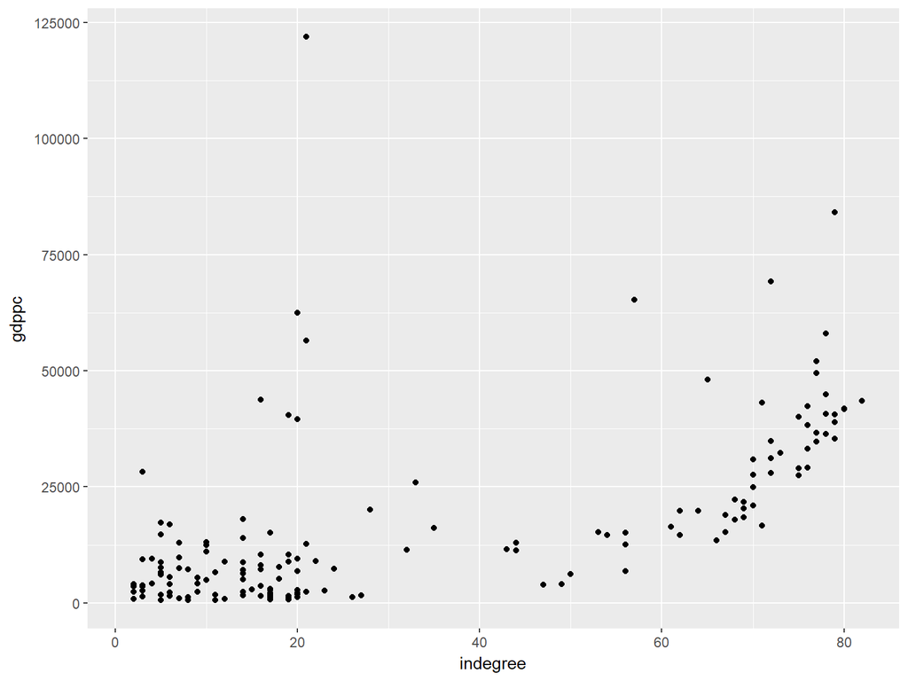

```r
ggplot2::qplot(x = indegree, y = gdppc, data = visa.df)
```

Grafiken lassen sich schnell erstellen aber der Code verrät uns nichts über die Bestandteile von Grafiken.

# Die Elemente des Grammar of Graphics

| Element | Beschreibung |
| --- | --- |
| Daten und Mappings | Daten und variablen |
| Geometrische Objekte | Darstellung von Data/Mappings |
| Skalen | standard, log, breaks |
| Koordinatensystem | kartesisch, polar, geog. |
| Statistische Transformation | Metrisch -> Kategorial (…) |
| Facets | Small multiples |

# Elemente: Data & Mapping

```r
visa.plot <- ggplot(data = visa.df)               # Wir sehen noch nichts.
```

Wir benötigen noch Variablen, die wir darstellen wollen. Im “Grammar of Graphics” spricht man davon, dass man ein **mapping** von Variables zu **aes**thetics vornimmt.

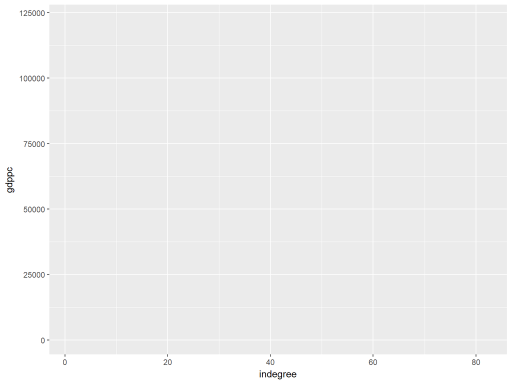

```r
visa.plot <- ggplot(data = visa.df,
                    mapping = aes(x = indegree, y = gdppc)) # Hier Mapping auf Position (aber                                                               # auch size, color etc. möglich)

visa.plot
```

# Elemente: Geometric objects I

Im nächsten Schritt müssen wir angeben, welche geometric objects (**geom**) unsere Variablen darstellen sollen. Dies sind bei einem Scatterplot z.B. Punkte.

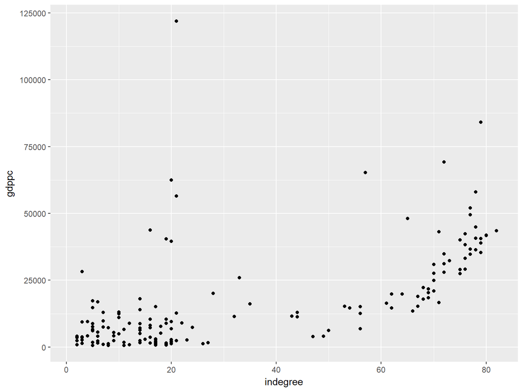

```r
visa.plot <- visa.plot +
  geom_point()

visa.plot
```

Wir erhalten den bekannten und, in diesem Fall, sinnvollen Scatterplot, welche wir zuvor mit `qplot` erstellt haben. Ähnlich wie in Sprachen lassen sich aber auch nicht sinnvolle Sätze (Grafiken) bilden:

> In `ggplot2` we can produce many plots that don’t make sense, yet are grammatically valid. This is no different than English, where we can create senseless but grammatical sentences like the angry rock barked like a comma (Wickham 2009: 30).

# Elemente: Geometric objects II

Unter http://ggplot2.tidyverse.org/reference/#section-layer-geoms finden sich verschiedene “geometric objects”, die wir verwenden könnten:

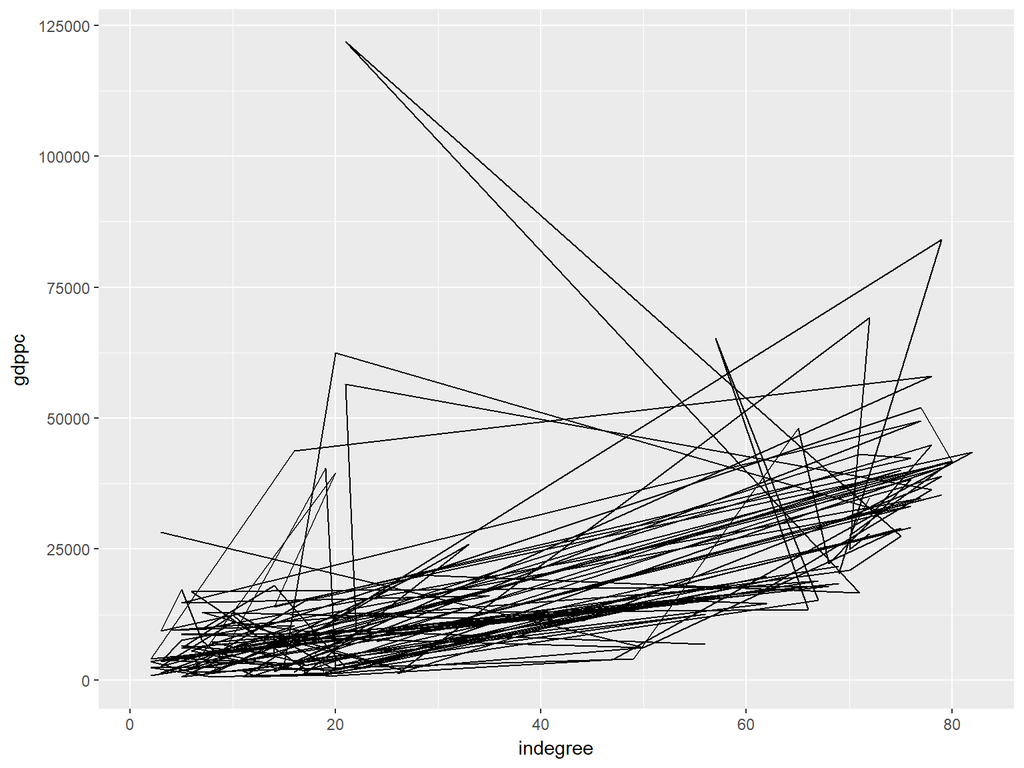

```r
ggplot(data = visa.df,
       mapping = aes(x = indegree, y = gdppc)) +
  geom_path()
```

Sieht mehr nach [accidental aRt](http://accidental-art.tumblr.com/) aus.

# Elemente: Scales

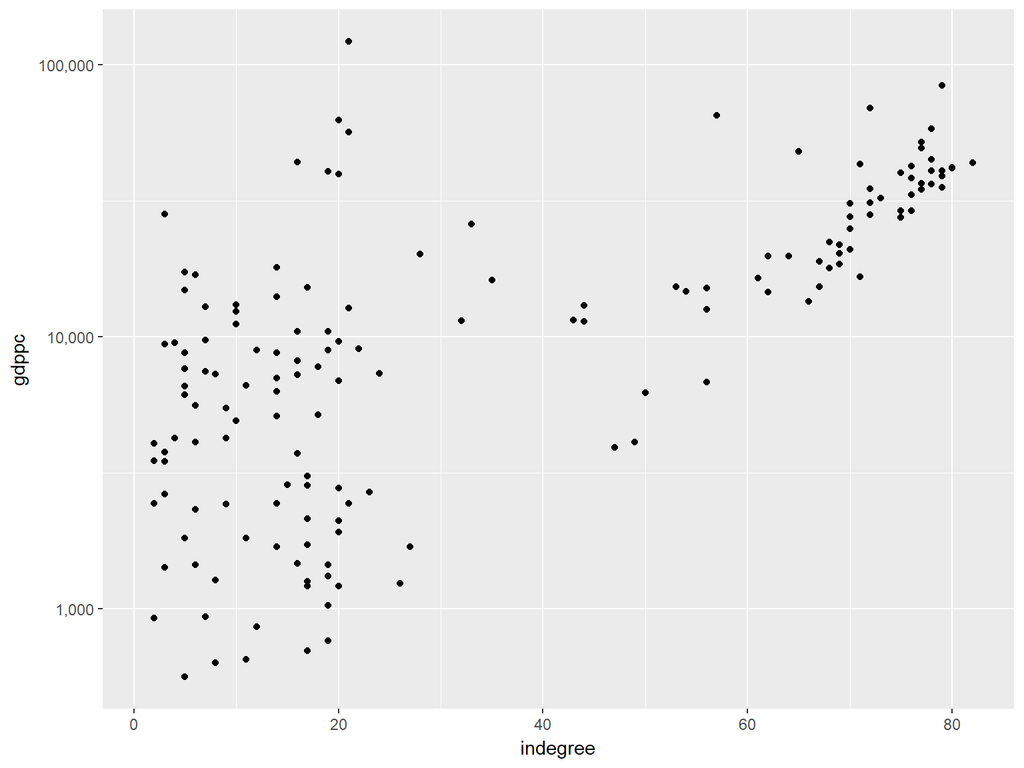

```r
library(scales)

ggplot(data = visa.df,
       mapping = aes(x = indegree, y = gdppc)) +
  geom_point() +
  scale_y_log10(labels = comma) # "labels = comma" prevents the use of scientific notation.
```

# Elemente: Coordinates

Koordinatensysteme “control how the axes and grid lines are drawn” (Wickham 2010: 13).

- Kartesische Koordinatensystem
- Polarkoordinaten (z.B. Kuchendiagramm)
- Geographische Koordinaten

# Elemente: Statistical transformations

Einige Grafiken verlangen, dass wir Variablen umwandeln, um diese darzustellen. Ein Beispiel sind Histogramme, welche metrische Variablen in “Kästen” einteilen und zählen.

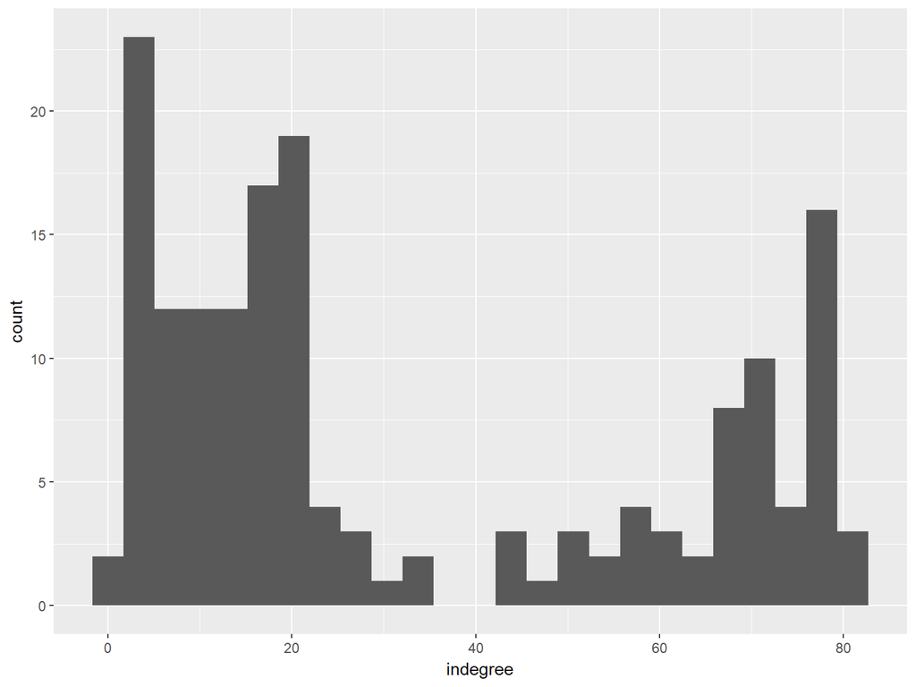

```r
ggplot(data = visa.df,
       mapping = aes(x = indegree)) +
  geom_histogram(stat = "bin", bins = 25)
```

Ich habe mir angewöhnt die Transformationen vorab vorzunehmen. Hierfür können wir dann wieder `dplyr` verwenden.

# Elemente: Facets I

Facetting wird verwendet, um “small multiples” (Tufte 1983[1997]: 161ff.) zu erstellen. Wir könnten z.B. annehmen, dass der Zusammenhang zwischen `indegree` und `gdppc` durch Machtgefälle zwischen Kontinenten “erklärt” wird.

Eine Farbe für die Zugehörigkeit zu einem Kontinent ergänzen.

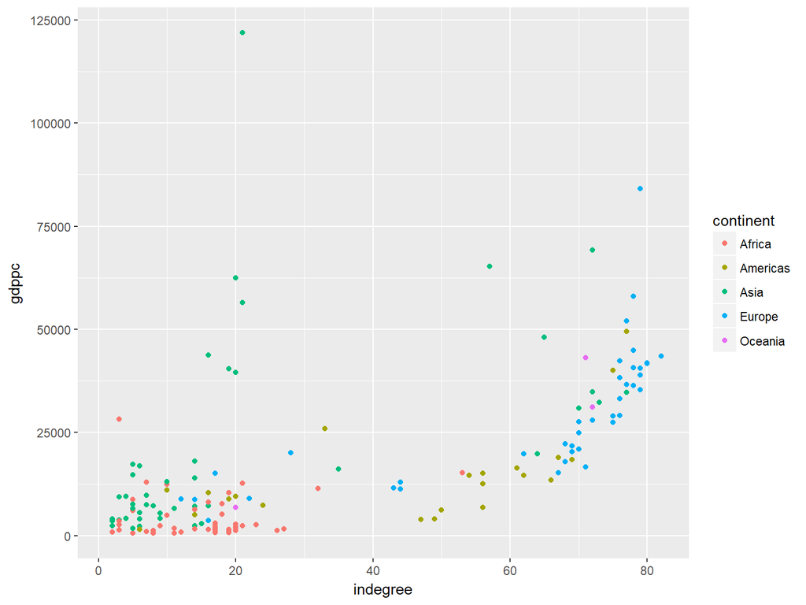

```r
ggplot(data = visa.df,
       mapping = aes(x = indegree, y = gdppc)) +
  geom_point(mapping = aes(color = continent))
```

# Elemente: Facets II

Unsere zweite Option wäre die Verwendung von “Facetting”:

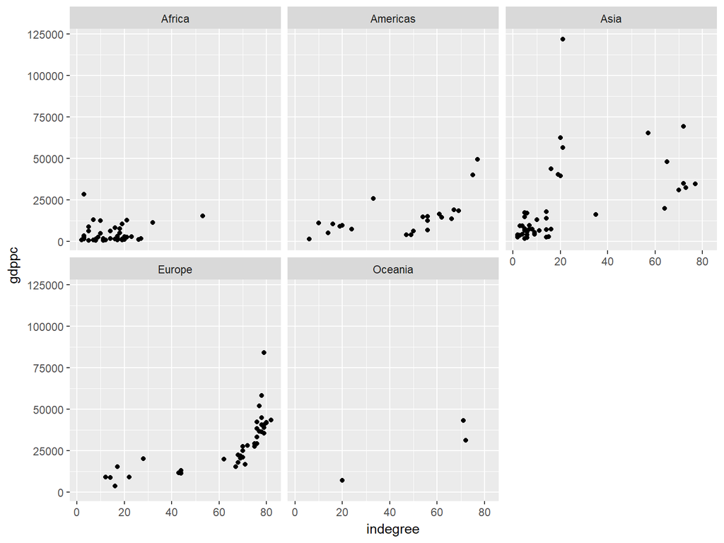

```r
ggplot(data = visa.df,
       mapping = aes(x = indegree, y = gdppc)) +
  geom_point() +
  facet_wrap(facets = ~continent)
```

# Ein komplexeres Beispiel: Minard

# Minard mit dem Grammar of Graphics I

Die Daten sind online verfügbar:

```r
min.troops <- read.csv(file = "https://raw.github.com/vincentarelbundock/Rdatasets/master/csv/HistData/Minard.troops.csv",
                       stringsAsFactors = FALSE)

min.city <- read.csv(file = "https://raw.github.com/vincentarelbundock/Rdatasets/master/csv/HistData/Minard.cities.csv",
                     stringsAsFactors = FALSE)
```

# Minard mit dem Grammar of Graphics II

| Element | Beschreibung |
| --- | --- |
| Daten | Daten: `min.troop`, `min.city` |
| Aesthetics | Aes: (1+2) `long`,`lat`, (1) `size`, `color`, `group`, (2) `label` |
| Geometrische Objekte | `geom_path`, `geom_text` |
| Skalen | standard (x, y) |
| Koordinatensystem | kartesisch (geog. auch möglich) |
| Statistische Transformation | (`size`) |
| Facets | / |

# Minard mit dem Grammar of Graphics III

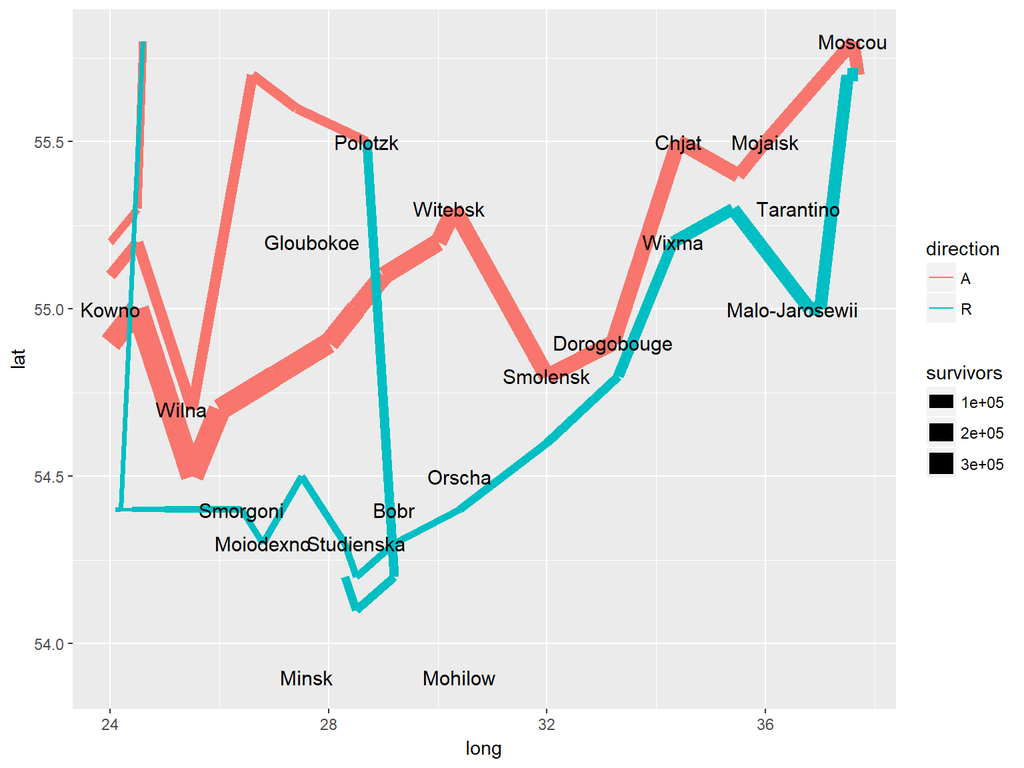

```r
ggplot() +
  geom_path(data = min.troops,                                                    # Layer 1
            mapping = aes(x = long, y = lat, size = survivors, color = direction,
                          group = group)) +
  geom_text(data = min.city,                                                      # Layer 2
            mapping = aes(x = long, y = lat, label = city), size = 4)
```

# Zur nächsten Sitzung

Zur Nachbereitung das [dritte Kapitel von Kieran Healy](http://socviz.co/makeplot.html#makeplot) Data Visualization for Social Science.